# Germination Experiment

Mario

07/12/2021

“A controlled microclimate contrast of three native and one highly invasive plant species in Southern California”

A controlled microclimate contrast of three native and one highly invasive plant species in Southern California Mario Zuliani1*, Laura Brussa, Jessica Cunsolo, Angela Zuliani, and Christopher J. Lortie1. 1Department of Biological Science, York University, 4700 Keele St, Toronto, ON M3J 1P3, Canada Question: How do increasing ambient temperature in arid ecosystems influence both the successive germination and total biomass of 3 natives and 1 exotic annual plant species.

Location: Greenhouse simulation conditions within the Carrizo Plain National Monument, California, USA (35.117985, -119.608762)

Methods: The effects of temperature were tested on 3 native, Salvia columbariae, Layia platyglossa, Phacelia tanacetifolia and 1 exotic plant species, Bromus rubens independently over a 6-week growing period in a temperature controlled greenhouse in 2021. 210 individual replicates were conducted across an increasing temperature gradient meant to simulate the arid ecosystems of Southern California. Hourly temperature was recorded through ambient temperature pendants. Annual biomass was then recorded at the conclusion of each 6-week trial.

Conclusion: These findings suggest that increases in ambient temperature due to global warming can have negative impacts on both native and exotic plant establishment and succession. Analyzing the performance and establishment of these annual species is essential to understanding local plant community composition while determining the responses both native and exotic annuals have to increasing abiotic stressors within arid/semi-arid ecosystems. Specifically understanding how increasing ambient temperature influences exotic annual establishment can be vital knowledge for managing the spread and establishment of these species.

Key Words: Intraspecific Association, Desert, Grassland, Greenhouse, Temperature, Bromus rubens, Exotic Species, Restoration

```r
###Packages for future work
library(rmarkdown)
library(ggmap)
```

```r
library(ggplot2)
library(tidyverse)
library(dplyr)
library(MASS)
library(ggpubr)
library(emmeans)
```

```r
##Prep Temp Data
Layia <- read.csv("All Temp Data.csv")
Brome <- read.csv("Brome Temp Sheet.csv")
Salvia <- read.csv("Salvia Temp Sheet.csv")
Phacelia <- read.csv("Phacelia Temp Sheet.csv")

###Merge all species temp data
Temp <- merge(Layia, Brome, all = TRUE)
Temp <- merge(Temp, Salvia, all = TRUE)
Temp <- merge(Temp, Phacelia, all = TRUE)

###Set up SD and SE
se_temp <- sd(Temp$temperature)/sqrt(length(Temp$temperature))
Temp$se <- se_temp

###Get mean and max temp
Temp <- Temp %>%
  group_by(as.character(temp), species, pendant_ID, se) %>%
  summarise(mean_temp = mean(temperature), max_temp = max(temperature))
```

[output not shown]

```r
names(Temp)[1] <- "temp"

###Output file
#write.csv(Temp, "Temp.csv")
```

```r
###Clean up Temperature and determine the mean and max for each pendant.
Temp2 <- read.csv("Temp_2.csv")
```

```r
#Prep Germination Data and Combine With Temp Data
#Germ <- read.csv("Final Germination.csv")
#final <- merge(Germ, Temp2, all = TRUE)

#write.csv(final, "final.csv")
final <- read.csv("final.csv")
```

###Data Viz

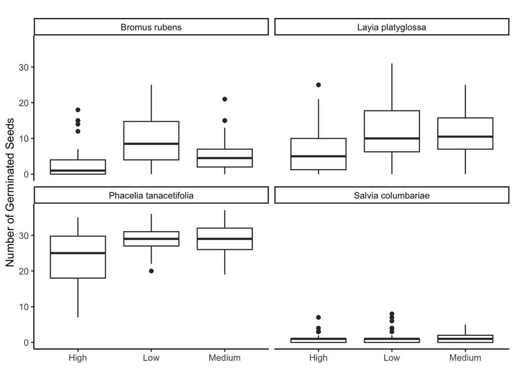

```r
###Temperature vs Number of Germinated Individuals in 6 weeks by species
TempFactor <- ggplot(final, aes(temp, germination),show.legend=FALSE) +
  geom_boxplot() +
  facet_wrap(~species)+
  scale_color_brewer(palette = "Set1") + theme_classic() + labs(tag = "")+
  theme(axis.title.x = element_blank()) +
  geom_smooth(method = lm, se = TRUE) +
  labs(x = "Temperature", y = "Number of Germinated Seeds")
TempFactor
```

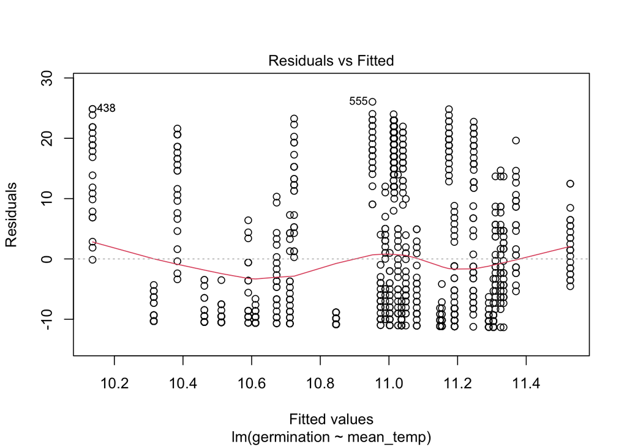

```r
###Plotting the lm
plot(lm(germination ~ mean_temp, data = final), which = 1)
```

```r
germination_poly <- lm(germination ~ mean_temp + I(mean_temp^2), data = final)

library(car)
library(broom)
Anova(germination_poly)
```

```
## Anova Table (Type II tests)
##
## Response: germination
##                Sum Sq  Df F value   Pr(>F)
## mean_temp         946   1  7.6086 0.005936 **
## I(mean_temp^2)    916   1  7.3724 0.006760 **
## Residuals      104027 837
## ---
## Signif. codes:  0 '***' 0.001 '**' 0.01 '*' 0.05 '.' 0.1 ' ' 1
```